# Supplementary File 2: Runtime performance

Zuguang Gu ( z.gu@dkfz.de )

2023-11-15

In this document, we benchmark the runtime performance of **simona** on ontologies with various sizes (i.e., on the level of 1K, 10K, 100K, 1M).

```r
library(simona)
set.seed(123)
```

We write a small function which applies the `"Sim_WP_1994"` similarity method. `"Sim_WP_1994"` is based on the DAG structure where it uses the longest distance from root to the lowest common ancestor (LCA) term (i.e. the depth of LCA) and the longest distance from the LCA term to the two terms.

Denote two terms as $a$ and $b$, their LCA term as $c$, $\delta(c)$ is the depth of $c$ in the DAG, i.e. the longest distance from the root term, $\mathrm{len}(c, a)$ is the longest distance from $c$ to $a$, the `"Sim_WP_1994"` similarity is calculated as:

$$\mathrm{Sim}(a, b) = \frac{2*\delta(c)}{\mathrm{len}(c, a) + \mathrm{len}(c, b) + 2*\delta(c)}$$

```r
benchmark_runtime = function(dag, by = 200, max = 10000) {
    invisible(dag_depth(dag))  # depth will be cached

    n_terms = dag_n_terms(dag)
    k = seq(by, min(max, floor(n_terms/by)*by), by = by)
    t = rep(NA_real_, length(k))
    for(i in seq_along(k)) {
        message(k[i], "/", max(k), "...")
        terms = sample(n_terms, k[i]) # numeric indicies are also allowed
        t[i] = system.time(term_sim(dag, terms, method = "Sim_WP_1994"))[3]
    }
    data.frame(k = k, t = t)
}
```

In the common settings when we import ontology datasets, we set `remove_rings = TRUE` to remove rings and `remove_cyclic_paths = TRUE` to remove cyclic links.

## Pathway Ontology

The `pw.owl` file is downloaded from http://obofoundry.org/ontology/pw.html. It contains several thousands of terms.

```r
dag = import_owl("~/workspace/ontology/OBOFoundry/pw/pw.owl",
    remove_rings = TRUE, remove_cyclic_paths = TRUE)
dag
```

```
## An ontology_DAG object:
##   Source: http://purl.obolibrary.org/obo/pw.owl, http://purl.obolibrary.org/obo/pw/7.52/pw.owl
##   2561 terms / 3142 relations
##   Root: ~~all~~
##   Terms: PW:0000001, PW:0000002, PW:0000003, PW:0000004, ...
##   Max depth: 10
##   Avg number of parents: 1.23
##   Aspect ratio: 78.11:1 (based on the longest distance to root)
##                 92:1 (based on the shortest distance to root)
##   Relations: is_a
##
## With the following columns in the metadata data frame:
##   id, short_id, name, namespace, definition
```

In the plot, a smooth line by loess fit is added.

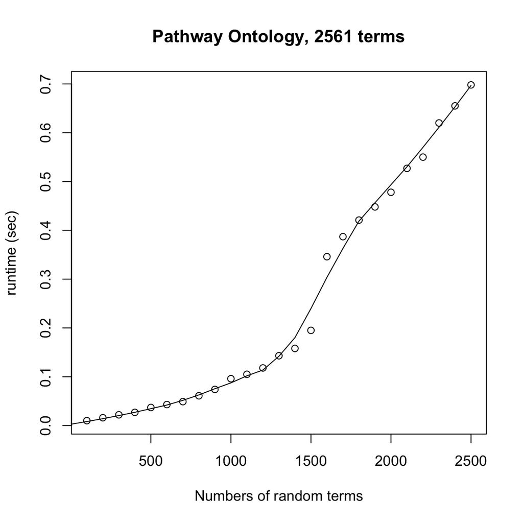

Figure S2-1. Runtime performance of simona on the Pathway Ontology.

```r
df = benchmark_runtime(dag, by = 100)
plot(df$k, df$t, xlab = "Numbers of random terms", ylab = "runtime (sec)",
    main = paste0("Pathway Ontology, ", dag_n_terms(dag), " terms"))
x = c(0, df$k)
y = c(0, df$t)
fit = loess(y ~ x, span = 0.5)
lines(x, predict(fit))
```

## Gene Ontology

Ontology is directly from the **GO.db** package. We use the Biological Process (BP) namespace. To be consistent to other ontologies under test, we only take the `"is_a"` relation type. It contains several tens of thousands of terms.

```r
dag = create_ontology_DAG_from_GO_db(relations = NULL)
dag
```

```
## An ontology_DAG object:
##   Source: GO BP / GO.db package 3.17.0
##   27942 terms / 50938 relations
##   Root: GO:0008150
##   Terms: GO:0000001, GO:0000002, GO:0000003, GO:0000011, ...
##   Max depth: 16
##   Avg number of parents: 1.82
##   Aspect ratio: 385.17:1 (based on the longest distance to root)
##                 751.33:1 (based on the shortest distance to root)
##   Relations: is_a
##
## With the following columns in the metadata data frame:
##   id, name, definition
```

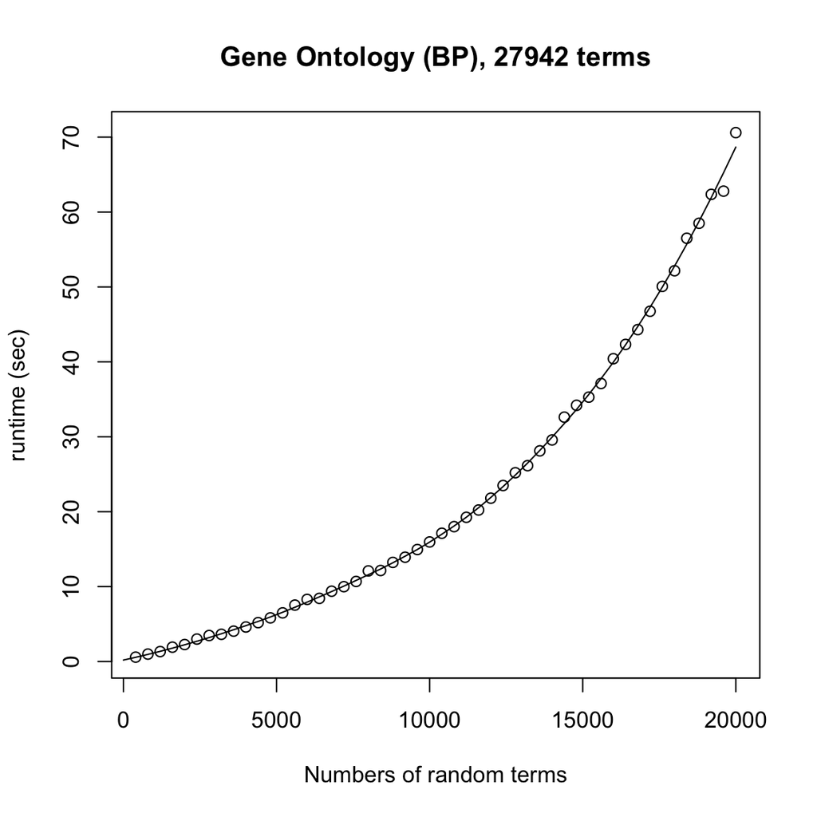

Figure S2-2. Runtime performance of simona on the Gene Ontology, biological process namespace.

```r
df = benchmark_runtime(dag, by = 400, max = 20000)
plot(df$k, df$t, xlab = "Numbers of random terms", ylab = "runtime (sec)",
    main = paste0("Gene Ontology (BP), ", dag_n_terms(dag), " terms"))
x = c(0, df$k)
y = c(0, df$t)
fit = loess(y ~ x, span = 0.5)
lines(x, predict(fit))
```

## Chemical Entities of Biological Interest

The `chebi.obo` file is dowloaded from http://obofoundry.org/ontology/chebi.html. It contains several hundreds of thousands of terms.

```r
dag = import_obo("~/workspace/ontology/OBOFoundry/chebi/chebi.obo",
    remove_rings = TRUE, remove_cyclic_paths = TRUE)
dag
```

[figure not shown]

Figure S2-3. Runtime performance of simona on the Chemical Entities of Biological Interest.

```r
df = benchmark_runtime(dag, by = 400, max = 20000)
plot(df$k, df$t, xlab = "Numbers of random terms", ylab = "runtime (sec)",
    main = paste0("Chemical Entities of Biological Interest, ", dag_n_terms(dag), " terms"))
x = c(0, df$k)
y = c(0, df$t)
fit = loess(y ~ x, span = 0.5)
lines(x, predict(fit))
```

## NCBI organismal classification

The `ncbitaxon.owl` file is downloaded from http://obofoundry.org/ontology/ncbitaxon.html. It contains several millions of terms.

```r
dag = import_owl("~/workspace/ontology/OBOFoundry/ncbitaxon/ncbitaxon.owl",
    remove_rings = TRUE, remove_cyclic_paths = TRUE)
dag
```

[figure not shown]

Figure S2-4. Runtime performance of simona on the NCBI organismal classification.

```r
df = benchmark_runtime(dag, by = 400, max = 20000)
plot(df$k, df$t, xlab = "Numbers of random terms", ylab = "runtime (sec)",
    main = paste0("NCBI organismal classification, ", dag_n_terms(dag), " terms"))
x = c(0, df$k)
y = c(0, df$t)
fit = loess(y ~ x, span = 0.5)
lines(x, predict(fit))
```

## Benchmark on OBO Foundry ontologies

Similarly, we benchmark all OBO Foundry ontologies with numbers of terms larger than 1000. We set 50 different numbers of random terms to test, from 100 to `min(20000, dag_n_terms(dag))`. Here the result is already generated and saved in `"runtime_OBOFoundry_all.RData"`. The script for generating this file is run_time_OBOFoundry.R. The plots for individual ontologies can be found in the “OBO Foundry gallery” document.

There are two objects in `"runtime_OBOFoundry_all.RData"`:

- `lt`: a list of two-column data frames which contain numbers of random terms to test and corresponding runtime.
- `df`: a data frame that contains meta-information of each ontology.

```r
load("runtime_OBOFoundry_all.RData")
length(lt)
```

```
## [1] 99
```

```r
head(names(lt))
```

```
## [1] "ado"       "agro"      "aism"      "apollo_sv" "aro"       "bcgo"
```

```r
head(lt[[1]])
```

```
##     k     t n_an
## 1 100 0.009  267
## 2 137 0.009  314
## 3 175 0.013  382
## 4 213 0.041  419
## 5 251 0.030  494
## 6 289 0.043  527
```

```r
head(df)
```

```
##                                                                       file
## ado                   /Users/guz/workspace/ontology/OBOFoundry/ado/ado.owl
## agro                /Users/guz/workspace/ontology/OBOFoundry/agro/agro.owl
## aism                /Users/guz/workspace/ontology/OBOFoundry/aism/aism.obo
## apollo_sv /Users/guz/workspace/ontology/OBOFoundry/apollo_sv/apollo_sv.owl
## aro                   /Users/guz/workspace/ontology/OBOFoundry/aro/aro.owl
## bcgo                /Users/guz/workspace/ontology/OBOFoundry/bcgo/bcgo.owl
##                  id      basename type     method n_terms n_relations
## ado             ado       ado.owl  owl import_owl    1960        2340
## agro           agro      agro.owl  owl import_owl    4118        4965
## aism           aism      aism.obo  obo import_obo    6608       10296
## apollo_sv apollo_sv apollo_sv.owl  owl import_owl    1608        1613
## aro             aro       aro.owl  owl import_owl    6897        7003
## bcgo           bcgo      bcgo.owl  owl import_owl    2268        2856
##           avg_parents avg_children   asp1   asp2 depth_max depth_q99
## ado          1.194487     4.804928  39.89  72.42        30        18
## agro         1.205975     2.602201  21.77  24.80        36        31
## aism         1.558347     3.031802  37.00  41.41        41        29
## apollo_sv    1.003734     2.320863   8.64   8.67        37        33
## aro          1.015516     8.603194 385.75 378.62         8         8
## bcgo         1.259815     3.352113  19.06  40.46        19        17
```

Different ontologies have different ranges of runtime. To make them comparable, we scale values on x-axis (i.e. numbers of terms) and values on y-axis (runtime) both into the range of `[0, 1]`.

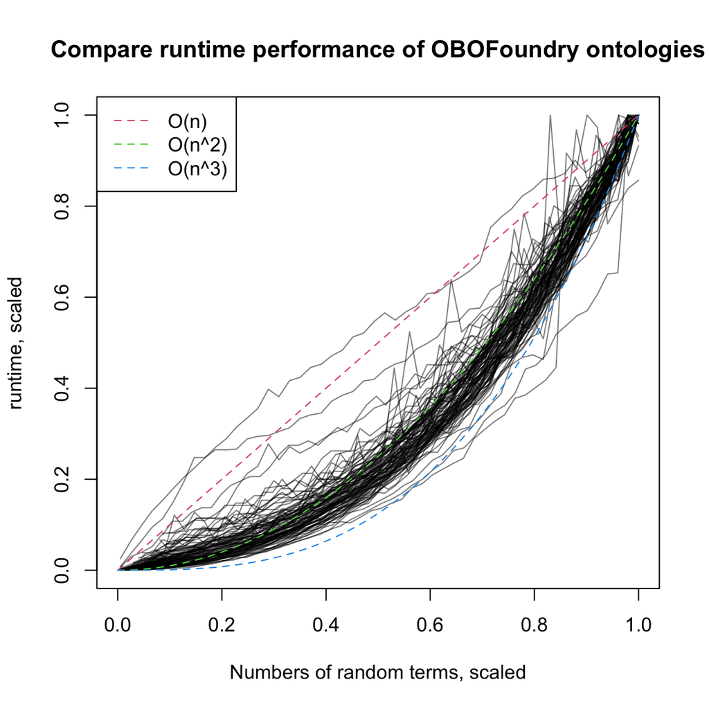

Figure S2-5. Compare runtime performance on various ontologies. Runtime performance is scaled into [0, 1] in the plot.

```r
plot(NULL, xlim = c(0, 1), ylim = c(0, 1),
    xlab = "Numbers of random terms, scaled", ylab = "runtime, scaled",
    main = "Compare runtime performance of OBOFoundry ontologies")
for(i in seq_along(lt)) {
    x = lt[[i]]$k
    y = lt[[i]]$t
    x = x/max(x)
    y = y/max(y)
    lines(x, y, col = "#00000080")
}
curve(x^1, from = 0, to = 1, col = 2, lty = 2, add = TRUE)
curve(x^2, from = 0, to = 1, col = 3, lty = 2, add = TRUE)
curve(x^3, from = 0, to = 1, col = 4, lty = 2, add = TRUE)
legend("topleft", lty = 2, col = 2:4, legend = c("O(n)", "O(n^2)", "O(n^3)"))
```

In the plot, if a curve bends more to the bottom right of the plotting region, it means the time complexity is worse. The plot shows for most of the ontologies, **simona** has a non-linear time complexity for calculating the similarities, close to $O(n^2)$, but there are a few ontologies, on which **simona** shows a near-linear time complexity.

```r
rel_diff = function(x, y, max_x = NULL) {
    if(missing(y)) {
        y = x[[2]]
        x = x[[1]]
    }

    if(!is.null(max_x)) {
        l = x <= max_x
        x = x[l]
        y = y[l]
    }

    od = order(x)
    x = x[od]
    y = y[od]
    n = length(x)

    x = x/max(x)
    y = y/max(y)

    area = sum( 0.5*(x[2:n] - x[2:n - 1])*(y[2:n] + y[2:n - 1]) )

    0.5 - area
}
```

We find the time complexity on different ontologies is quite stable around $O(n^2)$, but for some large ontologies, the time complexity decreases close to linear.

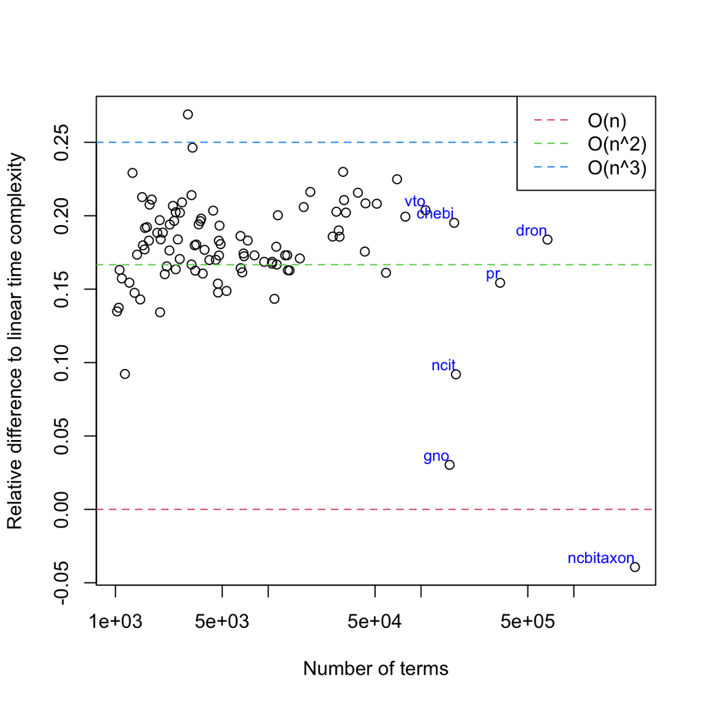

Figure S2-6. Relative time complexity to linear complexity. Ontologies with more than 100k terms are highlighted by their names.

```r
df$rel_diff = sapply(lt, rel_diff)

plot(df$n_terms, df$rel_diff, log = "x",
    xlab = "Number of terms",
    ylab = "Relative difference to linear time complexity")
abline(h = 0, lty = 2, col = 2)
abline(h = 1/6, lty = 2, col = 3)
abline(h = 1/4, lty = 2, col = 4)
l = df$n_terms > 100000
text(df$n_terms[l], df$rel_diff[l], df$id[l],
    adj = c(1, -0.4), col = "blue", cex = 0.8)
legend("topright", lty = 2, col = 2:4, legend = c("O(n)", "O(n^2)", "O(n^3)"))
```

However, this does not mean large ontology has better time complexity than smaller ones. Since in the benchmark procedures, the possible maximal number of random terms to pick (let’s call it `max_pick`) is set to 20000, with large ontologies with number of terms far larger than 20000, the number of picked terms is only a tiny proportion of total terms, thus the close-quadratic complexity is not obviously observable. Or when the number of terms picked is far smaller than the total number of terms, the time complexity is close to linear.

We can validate it by setting `max_pick` to small values such as 5000 and 1000, shown in the following plots. When `max_pick` becomes smaller, such reduction to linear complexity can be observed in more ontologies.

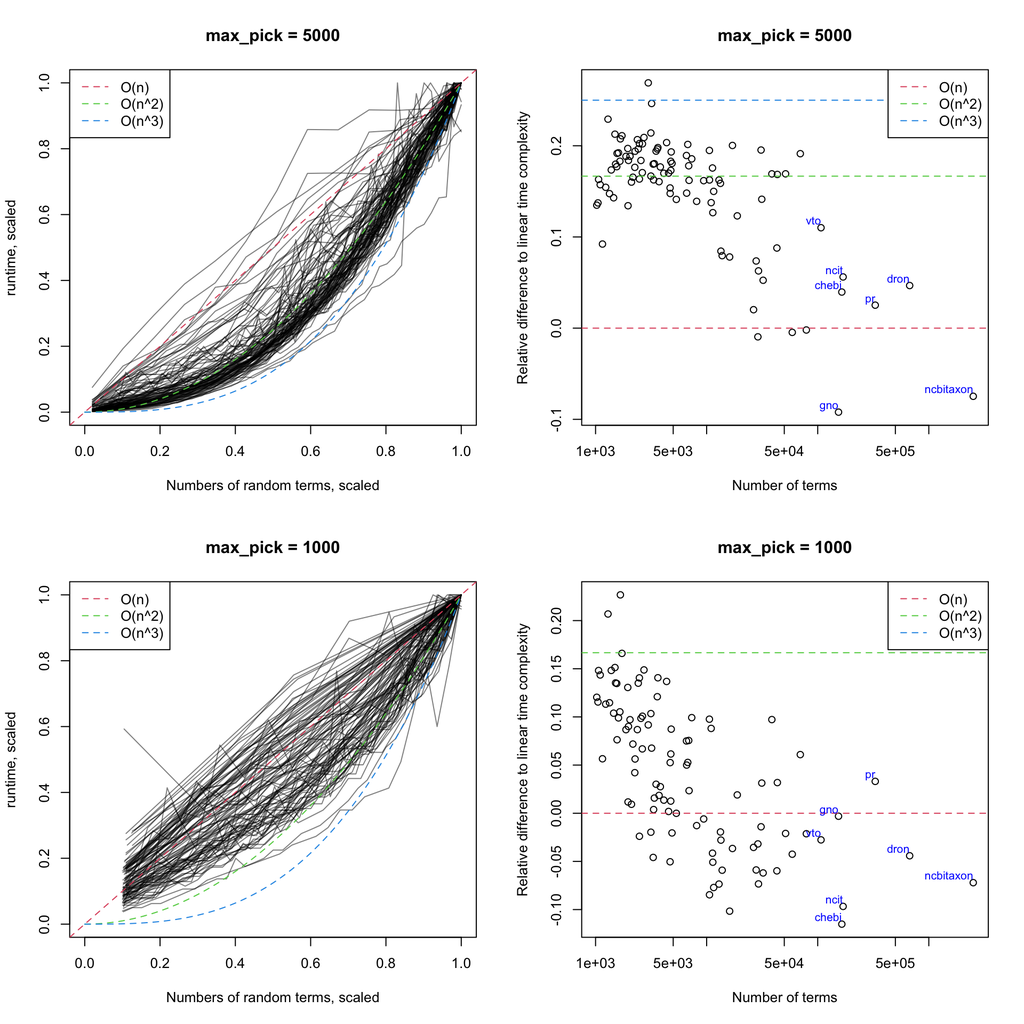

Figure S2-7. Compare the effect of max_pick on the time complexity.

In the comparison we performed previously, we fix the ontology and check the runtime performance when increasing the number of terms used for calculating similarities. Next we do in another dimension. We fix the number of random terms and we check the runtime performance on the size of the ontology.

We define the following `get_t_by_k()` function. For each ontology, the runtime $t$ of a given value of terms denoted as $k$ is predicted by a loess fit on number of terms and the corresponding runtime.

```r
get_t_by_k = function(k) {
    sapply(lt, function(df) {
        i0 = which(df$k == k)
        if(length(i0)) {
            df$t[i0]
        } else {
            ind1 = which(df$k < k)
            if(length(ind1) == 0) { # k is smaller than all df$k
                return(NA)
            }
            i1 = max(ind1)
            ind2 = which(df$k > k)
            if(length(ind2) == 0) { # k is larger than all df$k
                return(NA)
            }
            i2 = min(ind2)

            x = c(0, df$k)
            y = c(0, df$t)
            fit = loess(y ~ x, span = 0.5)
            predict(fit, k)

        }
    })
}
```

For example, if we randomly sample 500 terms from an ontology, the runtime performance on the size of the ontology would be:

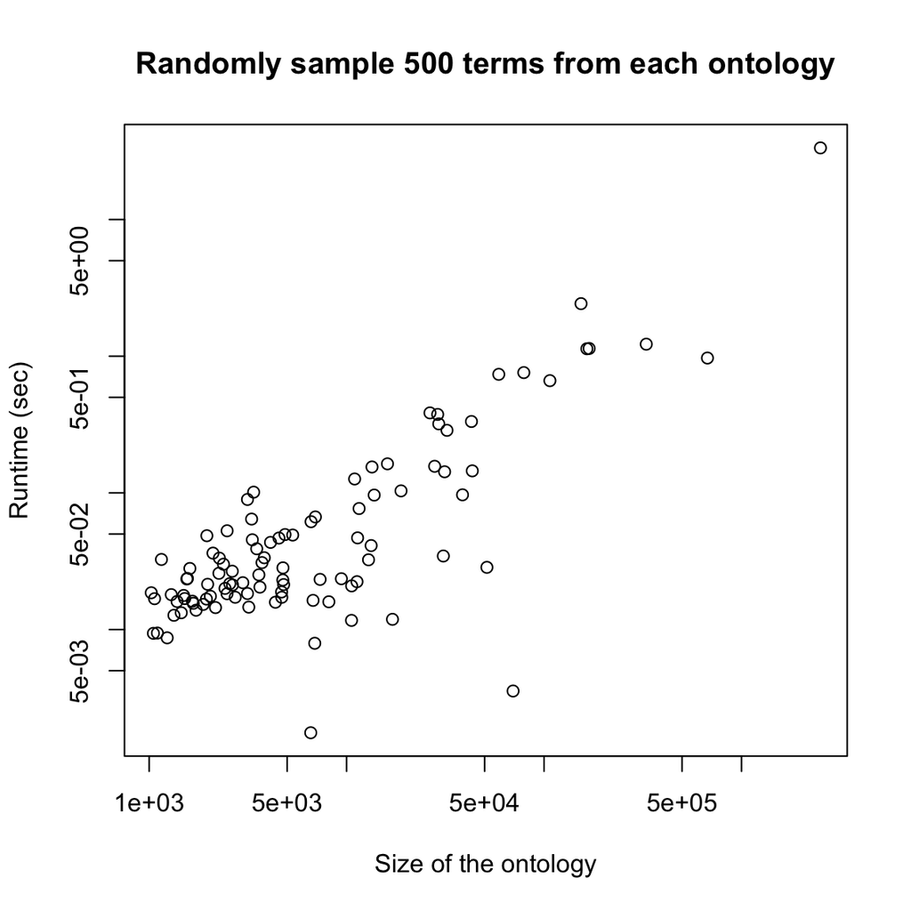

Figure S2-8. Runtime preformance on the size of ontologies. The number of terms for calculating semantic similarities is fixed to 500.

```r
t500 = get_t_by_k(500)
plot(df$n_terms, t500, log = "xy",
    xlab = "Size of the ontology", ylab = "Runtime (sec)",
    main = "Randomly sample 500 terms from each ontology")
```

In a double-log coordinate system, the runtime has a linear relation to the size of the ontology. We can perform a simple linear regression:

```r
lm(log(t500) ~ log(df$n_terms))
```

```
##
## Call:
## lm(formula = log(t500) ~ log(df$n_terms))
##
## Coefficients:
##     (Intercept)  log(df$n_terms)
##          -9.913            0.771
```

Let’s denote the runtime as $t$ and the size of the ontology as $n$, then they have a linear relation: $\log(t) = 0.77\log(n) - 9.91$. The slope is less than one, which means, if the ontology size increases by 2x, the runtime only increases by $2^{0.77}$ (1.71) times.

We can measure the relation between runtime and ontology size for a list of different $k$. The next function `compare_runtime_by_k()` calculates the runtime, makes the plot and performs linear regression for a given $k$. It returns the slope from the linear regression model.

```r
library(GetoptLong)
compare_runtime_by_k = function(k) {
    tt = get_t_by_k(k)
    plot(df$n_terms, tt, log = "xy",
        xlab = "n / Size of the ontology", ylab = "t / Runtime (sec)",
        main = qq("Randomly sample @{k} terms from each ontology"))
    fit = lm(log(tt) ~ log(df$n_terms))
    coef = round(coef(fit), 2)
    coef[1] = ifelse(sign(coef[1]) == 1, paste0("+", coef[1]), coef[1])
    text(min(df$n_terms), max(tt, na.rm = TRUE),
        qq("log(t) = @{coef[2]}*log(n)@{coef[1]}"), adj = c(0, 1))
    coef(fit)[2]
}
```

The list of $k$ we will compare is defined as follows.

```r
k = c(500, 600, 700, 800, 900, 1000, 2000, 3000,
      4000, 5000, 6000, 7000, 8000, 9000, 10000)
```

We make the plot for every $k$:

```r
coef = sapply(k, compare_runtime_by_k)
```

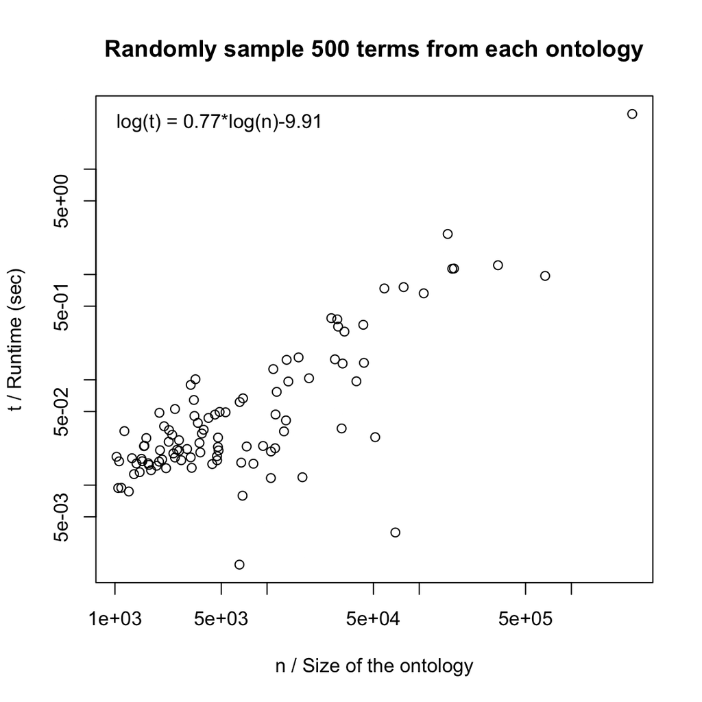

Figure S2-9. Runtime preformance on the size of ontologies, on a list of different k.

The slope coeffcient from the linear regression model measures the increasing rate of runtime when increasing the size of the ontology. We can check how fast the runtime increases when randomly sample different numbers of terms.

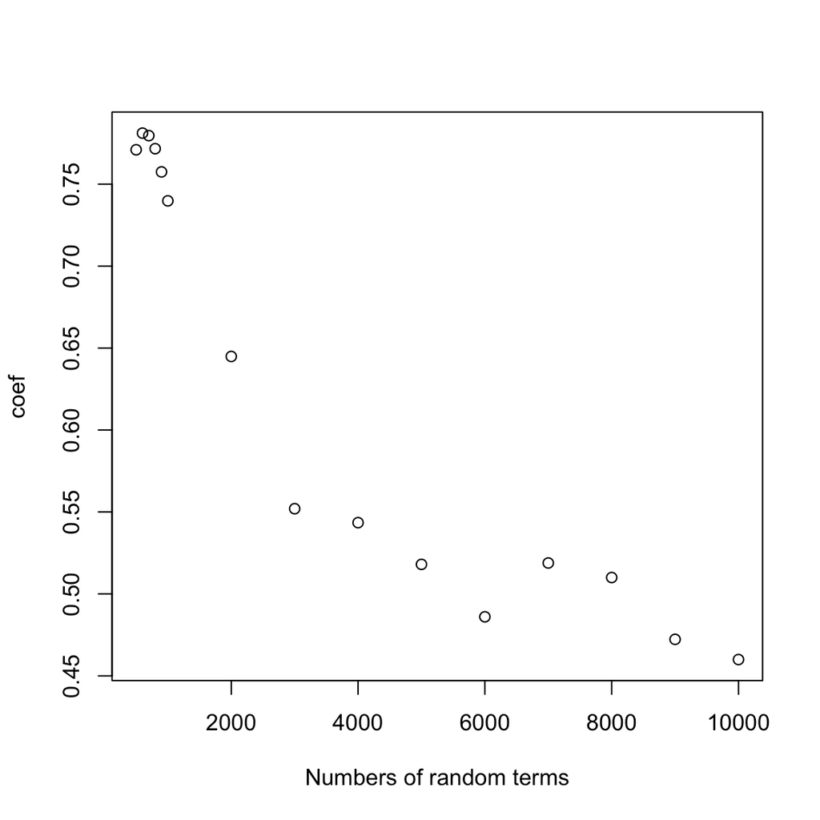

Figure S2-10. The increasing rate of runtime when increase the ontology size at different k.

```r
plot(k, coef, xlab = "Numbers of random terms", ylab = "coef")
```

It shows if randomly sample more terms from the ontology, the runtime increases slower and slower than the ontology size.

## Algorithm

First we describe the data structures:

1. All terms are represented in integer indices: `c(1, 2, 3, ..., n_all)`.
2. The parent/child relations are represented as two lists `lt_parents` and `lt_children`. `lt_parents[[i]]` is a vector of integer indices of its parent terms. E.g. if `lt_parents[[6]] = c(3, 4, 5)`, it means term 3, 4, 5 are parents of term 6. If you want to see term 3’s parents, directly go to `lt_parents[[3]]`. The structure is the same for `lt_children` where `lt_children[[i]]` is a vector of integer indicies of its child terms. Both `lt_parents` and `lt_children` have length of `n_all`. If the vector of `lt_parents[[i]]` is empty, it means term `i` is the root. If the vector of `lt_children[[i]]` is empty, it means term `i` is a leaf term.
3. In the following code, a variable with name starting with `l_` is a logical vector with length of `n_all`. E.g. a vector `l_all_ancestors` stores whether term `i` is an ancestor term. Also to simplify the description of the algorithm, we take the `l_*` vectors as pointers where a value change in place affects everywhere `l_*` variables are used.

We describe the algorithm for looking for LCA terms. The algorithm contains two steps:

**Input**: a vector of terms, already converted to integer indices. **Output**: A matrix of depth of LCA terms.

**Step 1**: find all ancestors of the given group of terms, including the terms themselves. They are union of ancestors of individual terms. We need to define three functions in this step.

```r
# nodes: an integer vector
ancestors_of_a_group = function(nodes) {
    l_all_ancestors = rep(FALSE, n_terms)
    for(node in nodes) {
        l_all_ancestor[node] = TRUE  # include the nodes themselves
        # it is the same as using `add_parents`, but we want to make it clear
        # that this is the union of ancestors of individual nodes
        add_ancestors(node, l_all_ancestor)
    }
    return(l_all_ancestor)
}

# node: a single integer scalar
# l_all_ancestor: a logical vector with length n_all (let's treat it as a pointer)
add_ancestors = function(node, l_all_ancestor) {
    add_parents(node, l_all_ancestor)
}

# node: a single integer scalar
# l_all_ancestor: a logical vector with length n_all (let's treat it as a pointer)
add_parents = function(node, l_all_ancestor) {
    parents = lt_parents[[node]] # a vector of integer indicies
    if(length(parents) > 0) {
        l_all_ancestor[parents] = TRUE
        for(p in parents) {
            add_parents(node, l_all_ancestor)
        }
    }
}

l_all_ancestors = ancestors_of_a_group(nodes)
all_ancestors = which(l_all_ancestors)
```

Looking for ancestors is applied recursively by `add_parents()`. Note again, we treat `l_all_ancestor` as a pointer so that it can be updated in the recursive parent lookup.

Step 1 generates two variables `l_all_ancestors` which is a logical vector representing whether term `i` is an ancestor term and `all_ancestors` which is the corresponding integer indices in `l_all_ancestors` of the `TRUE` values.

**Step 2**: All the common ancestors of `nodes` only exist in the set of `l_all_ancestors` or `all_ancestors`. We look for LCA in a top-down manner.

For each ancestor term `an` in `all_ancestors`, we first get its offspring terms but restricted in the background set `l_all_ancestors`. For a pair of terms in the offspring set, if both of them are also in `nodes`, the ancestor `an` is a common ancestor of the two terms. Then we compare the depth of `ca` and depth previously saved for the two offspring terms. We update it to the depth of `ca` if it is larger than the previous one.

Similarly, we need to define functions to look for offsprings, but this time we add another constrains of the backgroud. The implemntation is very similar as `add_ancestors()`.

```r
# nodes: an integer vector
# l_background: a logical vector with length n_all
offspring_within_background = function(node, l_background) {
    l_all_offspring = rep(FALSE, n_terms)
    l_all_offspring[node] = TRUE # include the term itself
    add_children(node, l_all_offspring, l_background)
}

# node: a single integer scalar
# l_all_offspring: a logical vector with length n_all (a pointer)
# l_background: a logical vector with length n_all
add_children = function(node, l_all_offspring, l_background) {
    children = lt_children[[node]] # a vector of integer indicies
    if(length(children) > 0) {
        l_all_offspring[children] = TRUE
        for(ch in children) {
            if(l_background[ch]) { # only continue if the child is in the background
                add_children(node, l_all_offspring, l_background)
            }
        }
    }
}
```

We pre-compute two variables. `l_nodes` corresponds to `nodes` but is a logical vector where the i<sup>th</sup> element is `TRUE` if term `i` is in `nodes`. `all_depth` is the depth of all terms in the ontology.

`LCA_depth` is the matrix that stores the depth of LCA terms. The initial values are set to zero.

```r
n = length(nodes)
LCA_depth = matrix(0, n, n)
diag(LCA_depth) = all_depth[nodes]

for(an in all_ancestors) {
    l_offspring = offspring_within_background(an, l_all_ancestors)
    offspring = which(l_offspring)
    no = length(offspring)

    for(i in 1:(no-1)) {
        if(l_nodes[ offspring[i] ]) {
            for(j in (i+1):no) {
                if(l_nodes[ offspring[j] ]) {
                    if(LCA_depth[i, j] < all_depth[an]) {
                        LCA_depth[i, j] = all_depth[an]
                        LCA_depth[j, i] = LCA_depth[i, j]
                    }
                }
            }
        }
    }
}
```

In this three levels of for-loop, in the triple (`ca`, `offspring[i]`, `offspring[j]`), `an` is always an common ancestor of `offspring[i]`, `offspring[j]`, while in other implementations, computations are also spent on the case where `an`is not the common ancestor.

The algorithm is also workable for finding MICA or calculating pairwise distance in the ontology.